# **CSCI218 Group 18 - Bank Marketing Prediction**

## **Team Members**

- **Joanne Yi Xuan Goh** (8038946)
- **Victor Soon Peng Jong** (8769229)
- **Jun Xian Bryan Lai** (8039331)
- **Ying Hui Lee** (8335187)
- **Huiting Liu** (8083149)
- **Shoong Chin Patrick Tan** (8083162)

## **Project Overview**

This project aims to **predict whether a customer will subscribe to a term deposit** using the **Bank Marketing dataset** from the **UCI Machine Learning Repository**. We will apply **machine learning techniques** to analyze the data, build predictive models, and evaluate their performance.

**Dataset Source:** [UCI Repository - Bank Marketing Dataset](https://archive.ics.uci.edu/ml/datasets/Bank+Marketing)

## **Objectives**

- **Perform Exploratory Data Analysis (EDA)**
- **Preprocess the data**
- **Train machine learning models**
- **Compare model performance**
- **Visualize key insights and predictions**

## **Machine Learning Models Used**

- **Logistic Regression**
- **Random Forest**
- **XGBoost**

# Imports

```python
from google.colab import drive
import pandas as pd
import numpy as np
from sklearn.preprocessing import StandardScaler
from sklearn.model_selection import train_test_split
import matplotlib.pyplot as plt
import seaborn as sns
from sklearn.linear_model import LogisticRegression
from sklearn.metrics import accuracy_score, confusion_matrix, classification_report
from sklearn.model_selection import GridSearchCV
from sklearn.metrics import make_scorer, recall_score
import pickle
import joblib
```

# Data Preprocessing

## Load Data

```python
# Mount Google Drive to Google Colab
drive.mount('/content/drive')
```

```python
# Define the correct file path
file_path = "/content/drive/My Drive/UOW/CSCI218 Group Project/dataset/bank-additional/bank-additional/bank-additional-full.csv"

# Load dataset (semicolon `;` as separator)
df = pd.read_csv(file_path, sep=";")

pd.set_option('display.max_columns', None)

# Display first few rows
df.head()

df_EDA = df.copy()
```

```python
# Check dataset information
df.info()

# Show basic statistics
df.describe()
```

```
<class 'pandas.core.frame.DataFrame'>
RangeIndex: 41188 entries, 0 to 41187
Data columns (total 21 columns):
 #   Column          Non-Null Count  Dtype
---  ------          --------------  -----
 0   age             41188 non-null  int64
 1   job             41188 non-null  object
 2   marital         41188 non-null  object
 3   education       41188 non-null  object
 4   default         41188 non-null  object
 5   housing         41188 non-null  object
 6   loan            41188 non-null  object
 7   contact         41188 non-null  object
 8   month           41188 non-null  object
 9   day_of_week     41188 non-null  object
 10  duration        41188 non-null  int64
 11  campaign        41188 non-null  int64
 12  pdays           41188 non-null  int64
 13  previous        41188 non-null  int64
 14  poutcome        41188 non-null  object
 15  emp.var.rate    41188 non-null  float64
 16  cons.price.idx  41188 non-null  float64
 17  cons.conf.idx   41188 non-null  float64
 18  euribor3m       41188 non-null  float64
 19  nr.employed     41188 non-null  float64
 20  y               41188 non-null  object
dtypes: float64(5), int64(5), object(11)
memory usage: 6.6+ MB
```

|  | age | duration | campaign | pdays | previous | emp.var.rate | cons.price.idx | cons.conf.idx | euribor3m | nr.employed |
| --- | --- | --- | --- | --- | --- | --- | --- | --- | --- | --- |
| count | 41188.00000 | 41188.000000 | 41188.000000 | 41188.000000 | 41188.000000 | 41188.000000 | 41188.000000 | 41188.000000 | 41188.000000 | 41188.000000 |
| mean | 40.02406 | 258.285010 | 2.567593 | 962.475454 | 0.172963 | 0.081886 | 93.575664 | -40.502600 | 3.621291 | 5167.035911 |
| std | 10.42125 | 259.279249 | 2.770014 | 186.910907 | 0.494901 | 1.570960 | 0.578840 | 4.628198 | 1.734447 | 72.251528 |
| min | 17.00000 | 0.000000 | 1.000000 | 0.000000 | 0.000000 | -3.400000 | 92.201000 | -50.800000 | 0.634000 | 4963.600000 |
| 25% | 32.00000 | 102.000000 | 1.000000 | 999.000000 | 0.000000 | -1.800000 | 93.075000 | -42.700000 | 1.344000 | 5099.100000 |
| 50% | 38.00000 | 180.000000 | 2.000000 | 999.000000 | 0.000000 | 1.100000 | 93.749000 | -41.800000 | 4.857000 | 5191.000000 |
| 75% | 47.00000 | 319.000000 | 3.000000 | 999.000000 | 0.000000 | 1.400000 | 93.994000 | -36.400000 | 4.961000 | 5228.100000 |
| max | 98.00000 | 4918.000000 | 56.000000 | 999.000000 | 7.000000 | 1.400000 | 94.767000 | -26.900000 | 5.045000 | 5228.100000 |

## Handling Missing Values

```python
# Print missing values
print(df.isnull().sum())
```

```
age               0
job               0
marital           0
education         0
default           0
housing           0
loan              0
contact           0
month             0
day_of_week       0
duration          0
campaign          0
pdays             0
previous          0
poutcome          0
emp.var.rate      0
cons.price.idx    0
cons.conf.idx     0
euribor3m         0
nr.employed       0
y                 0
dtype: int64
```

# Exploratory Data Analysis (EDA)

## Visualising Data Distribution

### Distribution of Subscription Outcome (y)

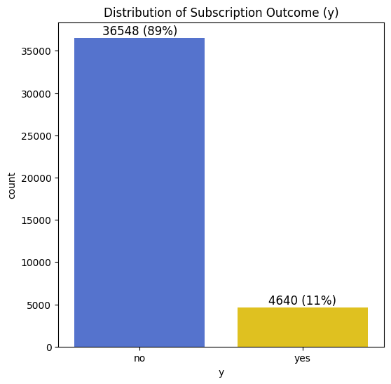

```python
plt.figure(figsize=(6, 6))
ax =sns.countplot(x=df_EDA['y'], hue=df_EDA['y'], palette=["royalblue", "gold"], legend=False)

# Add labels on top of bars
count_val = df_EDA['y'].value_counts()
percentage_val = df_EDA['y'].value_counts(normalize=True) * 100
for p, label in zip(ax.patches, count_val.index):
    ax.annotate(f'{count_val[label]} ({percentage_val[label]:.0f}%)',
                (p.get_x() + p.get_width() / 2., p.get_height()),
                ha='center', va='bottom', fontsize=12, color='black')

plt.title("Distribution of Subscription Outcome (y)")
plt.show()
```

**Observation(s):**

The distribution of subscription outcome (y = no) is 89% which is significantly more than (y = yes) 11%.

**Note(s) for Model Training:**

The distribution of subscription outcome (y) is imbalanced for consideration during model training.

```python
#  Function to plot the count and the percentage distribution of 'y' for each category

def plot_y_distribution_categorical(df, feature, xticks_rotation=0, xticks_ha='center'):
  # Count occurrences of 'y' for each feature category
  y_distribution_count = df.groupby(feature)['y'].value_counts().unstack()  # Absolute count
  y_distribution_percentage = df.groupby(feature)['y'].value_counts(normalize=True).unstack() * 100  # Convert to percentage

  # Plot the absolute count of 'y' for each 'unknown_count' category
  plt.figure(figsize=(12, 6))
  y_distribution_count.plot(kind='bar', stacked=True, color=["royalblue", "gold"])

  # Add total labels on top of each bar group
  for index, value in enumerate(y_distribution_count.sum(axis=1)):
      plt.text(index, value + 200, str(int(value)), ha='center', fontsize=10)

  plt.xlabel(f"{feature}", fontsize=12)
  plt.ylabel("Count of Rows", fontsize=12)
  plt.title(f"distribution of 'y' count based on {feature}", fontsize=14)
  plt.legend(title="Subscription Outcome (y)", loc="upper right", bbox_to_anchor=(1.4, 1))
  plt.xticks(rotation=xticks_rotation, ha=xticks_ha)
  plt.show()

  # Plot the percentage distribution of 'y' for each 'job' category
  plt.figure(figsize=(12, 6))
  y_distribution_percentage.plot(kind='bar', stacked=True, color=["royalblue", "gold"])

  # Add percentage labels on top of each bar group if percentage > 0%
  for bars in plt.gca().containers:
      for bar in bars:
          height = bar.get_height()
          if height > 0:
              plt.text(bar.get_x() + bar.get_width() / 2, bar.get_y() + height / 2, f"{height:.1f}%", ha='center', fontsize=8, color='black')

  plt.xlabel(f"{feature}", fontsize=12)
  plt.ylabel("Percentage (%)", fontsize=12)
  plt.title(f"distribution of 'y' percentage based on {feature}", fontsize=14)
  plt.legend(title="Subscription Outcome (y)", loc="upper right", bbox_to_anchor=(1.4, 1))
  plt.xticks(rotation=xticks_rotation, ha=xticks_ha)
  plt.show()
```

### Distribution of 'y' Based on Number of "unknown" Values

```python
# Create a column that stores the number of 'unknown' values in a row
df_EDA['unknown_count'] = df_EDA.apply(lambda row: sum(row.astype(str).str.lower() == 'unknown'), axis=1)

# Display first few rows to verify
df_EDA.head()
```

|  | age | job | marital | education | default | housing | loan | contact | month | day_of_week | duration | campaign | pdays | previous | poutcome | emp.var.rate | cons.price.idx | cons.conf.idx | euribor3m | nr.employed | y | unknown_count |
| --- | --- | --- | --- | --- | --- | --- | --- | --- | --- | --- | --- | --- | --- | --- | --- | --- | --- | --- | --- | --- | --- | --- |
| 0 | 56 | housemaid | married | basic.4y | no | no | no | telephone | may | mon | 261 | 1 | 999 | 0 | nonexistent | 1.1 | 93.994 | -36.4 | 4.857 | 5191.0 | no | 0 |
| 1 | 57 | services | married | high.school | unknown | no | no | telephone | may | mon | 149 | 1 | 999 | 0 | nonexistent | 1.1 | 93.994 | -36.4 | 4.857 | 5191.0 | no | 1 |
| 2 | 37 | services | married | high.school | no | yes | no | telephone | may | mon | 226 | 1 | 999 | 0 | nonexistent | 1.1 | 93.994 | -36.4 | 4.857 | 5191.0 | no | 0 |
| 3 | 40 | admin. | married | basic.6y | no | no | no | telephone | may | mon | 151 | 1 | 999 | 0 | nonexistent | 1.1 | 93.994 | -36.4 | 4.857 | 5191.0 | no | 0 |
| 4 | 56 | services | married | high.school | no | no | yes | telephone | may | mon | 307 | 1 | 999 | 0 | nonexistent | 1.1 | 93.994 | -36.4 | 4.857 | 5191.0 | no | 0 |

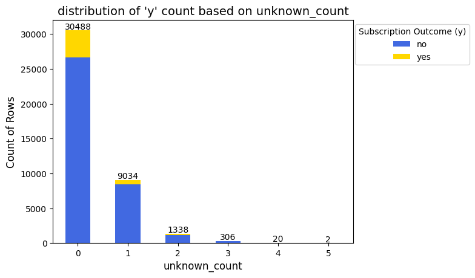

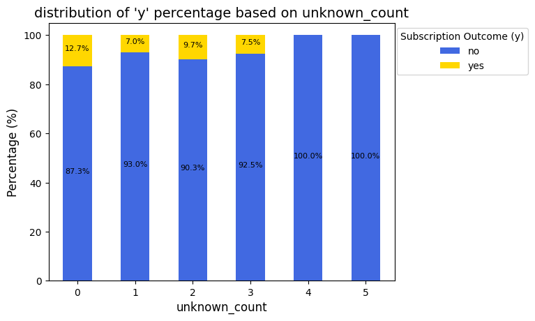

```python
# Plot the count and the percentage distribution of 'y' for each 'unknown_count' category
plot_y_distribution_categorical(df_EDA, 'unknown_count')
```

**Observation(s):**

- The percentage of subscribers (y = yes) varies across different unknown_count values.
- The more unknown values a row has, the lower the subscription rate (y = yes) tends to be.
- This suggests that having 'unknown' values may itself be an important predictor rather than just missing data.

**Note(s) for Model Training:**

- Keep the 'unknown' values as a category rather than imputing or dropping them as they may be useful for model prediction.

### Distribution of 'y' Across Different Job

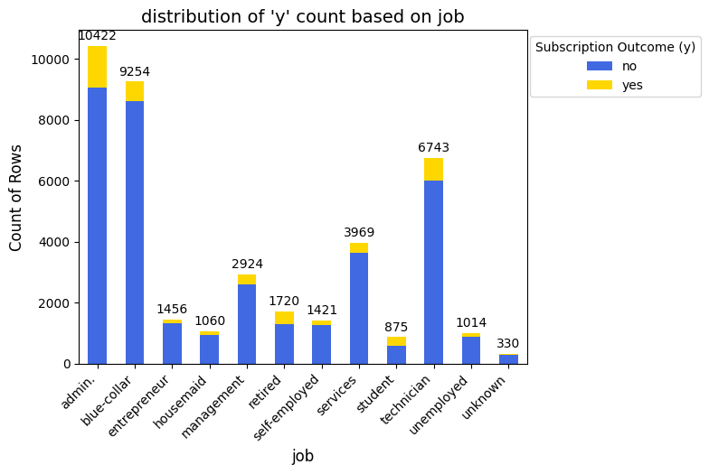

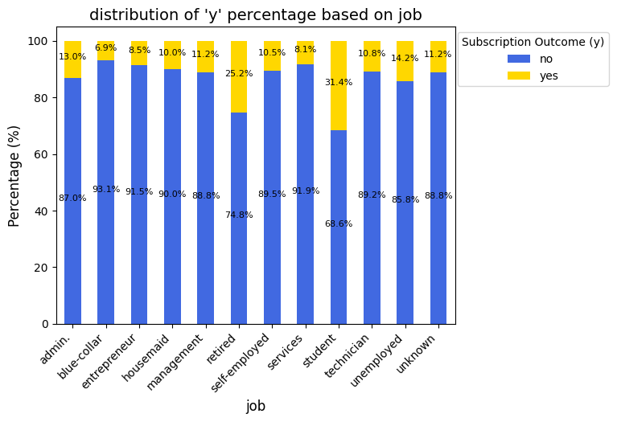

```python
# Plot the count and the percentage distribution of 'y' for each 'job' category
plot_y_distribution_categorical(df_EDA, 'job', 45, 'right')
```

**Observation(s):**

Across the job categories, retired and student have the highest percentage (>25%) of subscription outcome (y = yes) while blue-collar has the lowest percentage (<7%). This could be due to lower risk profile among retirees and students which leads to higher tendency for term deposit subscription.

**Note(s) for Model Training:**

Job seems to have some influence on the likelihood of subscription. To be used for model training.

### Distribution of 'y' Across Different Marital Status

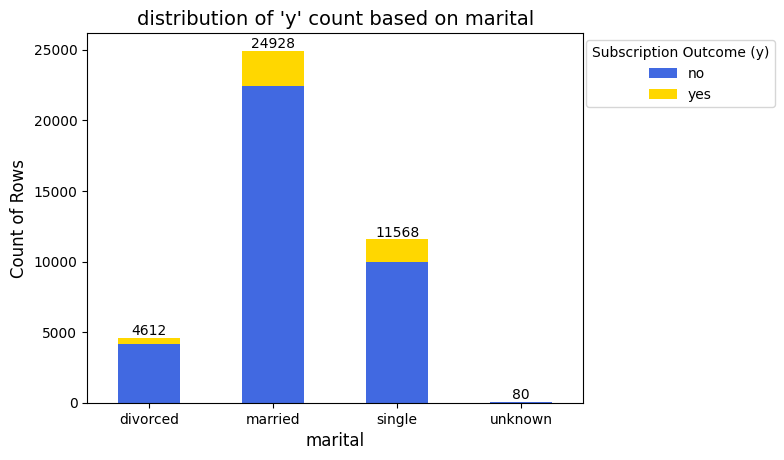

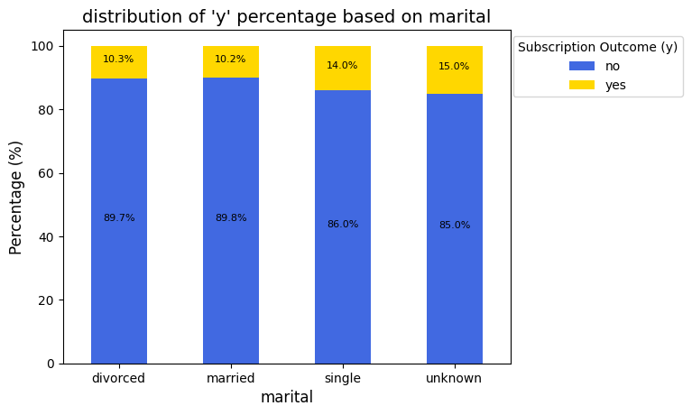

```python
# Plot the count and the percentage distribution of 'y' for each 'marital' category
plot_y_distribution_categorical(df_EDA, 'marital')
```

**Observation(s):**

Across the marital categories, the subscription outcome (y = yes) for divorced and married are approximately 10% while single and unknown are around 15%.

**Note(s) for Model Training:**

Marital status seems to have some influence on the likelihood of subscription. To be used for model training.

### Distribution of 'y' Across Different Education

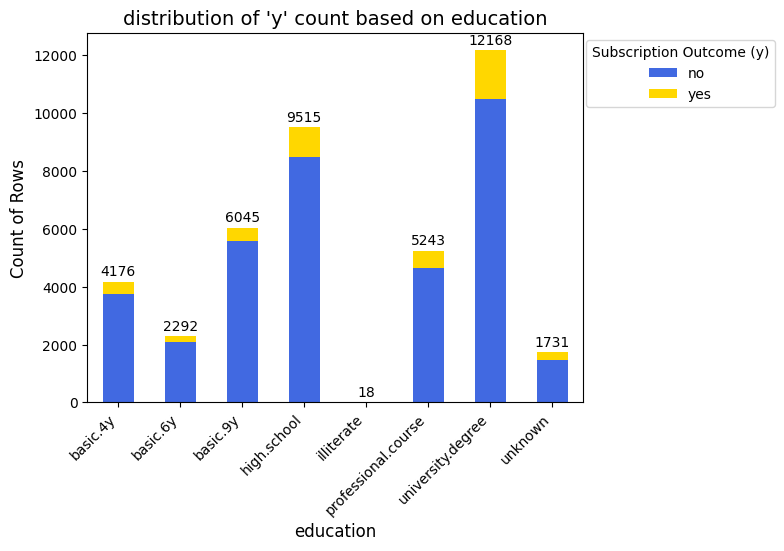

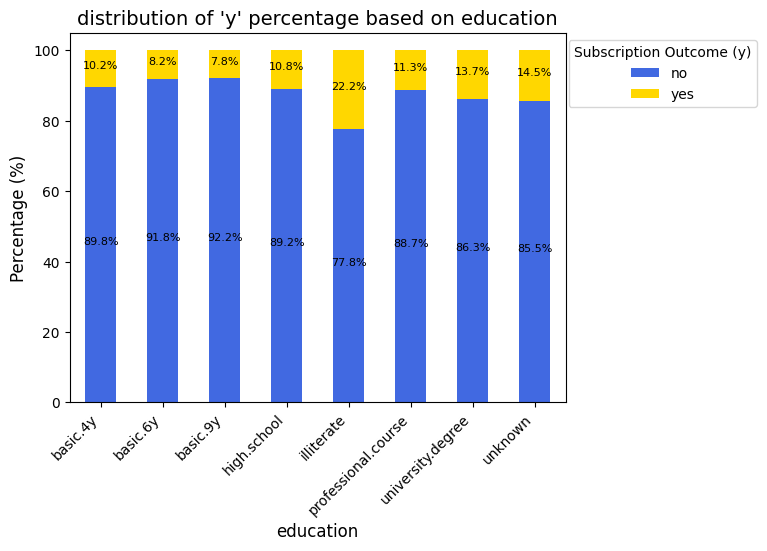

```python
# Plot the count and the percentage distribution of 'y' for each 'education' category
plot_y_distribution_categorical(df_EDA, 'education', 45, 'right')
```

**Observation(s):**

Across the education categories, the subscription outcome (y = yes) ranges from 7.8% to 22.2%. Based on current records, illiterate has the highest percentage of subscription outcome (y = yes) at 22.2%. However, this may not reflect the actual population statistics due to small sample of 18 records.

**Note(s) for Model Training:**

Education categories seem to have some influence on the likelihood of subscription. To be used for model training.

### Distribution of 'y' Based on Credit Default

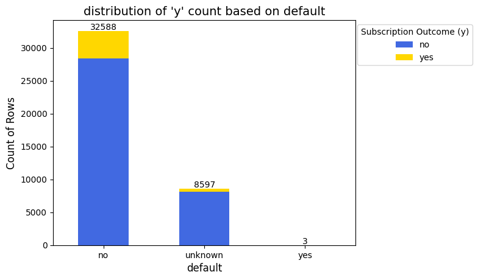

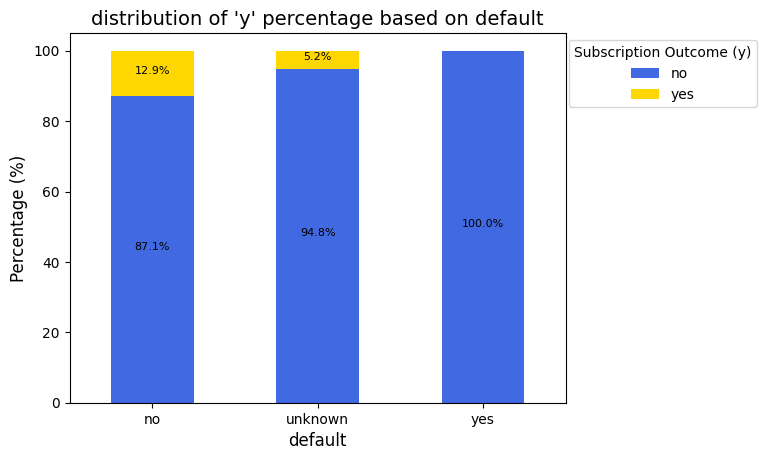

```python
# Plot the count and the percentage distribution of 'y' for each 'default' category
plot_y_distribution_categorical(df_EDA, 'default')
```

**Observation(s):**

Across the credit default categories, the subscription outcome (y = yes) ranges from 0% to 12.9%. Based on current records, having a credit line in default has a 0% subscription outcome (y = yes). However this may not reflect the actual population statistics due to small sample of 3 records.

**Note(s) for Model Training:**

Credit default categories seem to have some influence on the likelihood of subscription. To be used for model training.

### Distribution of 'y' Based on Housing Loan

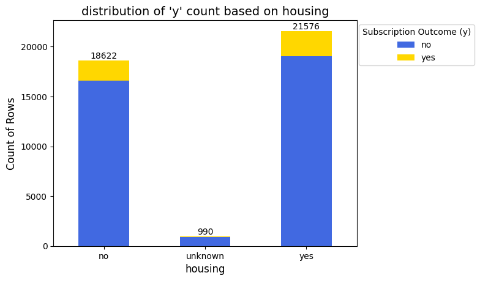

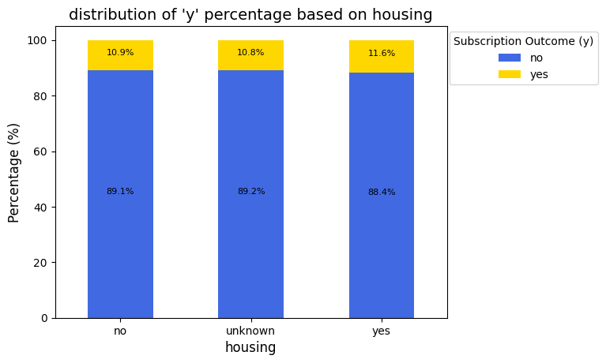

```python
# Plot the count and the percentage distribution of 'y' for each 'housing' category
plot_y_distribution_categorical(df_EDA, 'housing')
```

**Observation(s):**

Across the housing loan categories, the subscription outcome (y = yes) ranges from 10.8% to 11.6%. Has or does not have housing loan seem to have no significant difference on the subscription outcome (y = yes).

**Note(s) for Model Training:**

Housing loan categories seem to have little influence on the likelihood of subscription. Potentially could be excluded for model training after examing the feature importance.

### Distribution of 'y' Based on Personal Loan

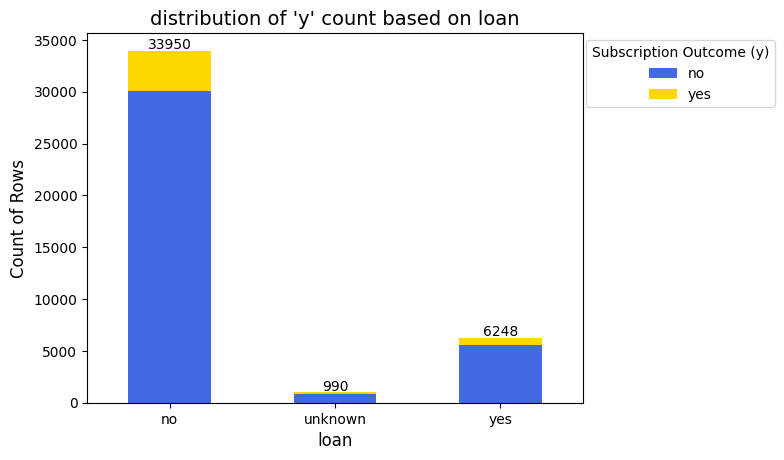

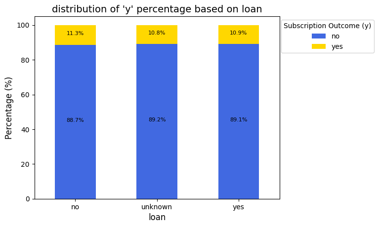

```python
# Plot the count and the percentage distribution of 'y' for each 'loan' category
plot_y_distribution_categorical(df_EDA, 'loan')
```

**Observation(s):**

Across the personal loan categories, the subscription outcome (y = yes) ranges from 10.8% to 11.3%. Having or not having personal loan seem to have no significant difference on the subscription outcome (y = yes).

**Note(s) for Model Training:**

Personal loan categories seem to have little influence on the likelihood of subscription. Potentially could be excluded for model training after examing the feature importance.

### Distibution of 'y' Based on Contact Communication Type

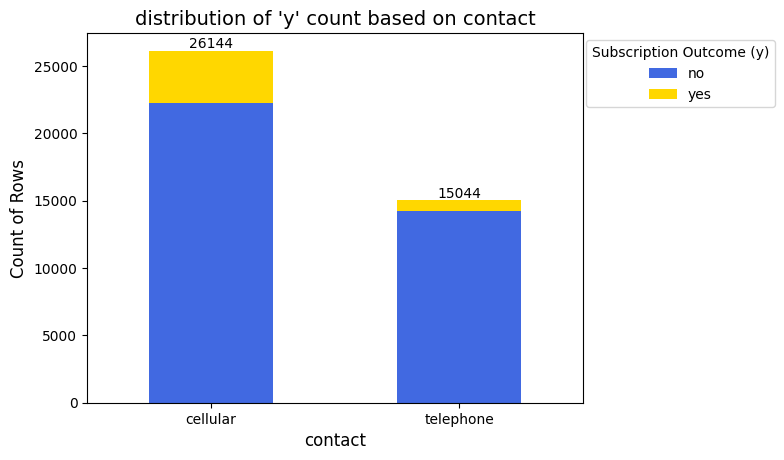

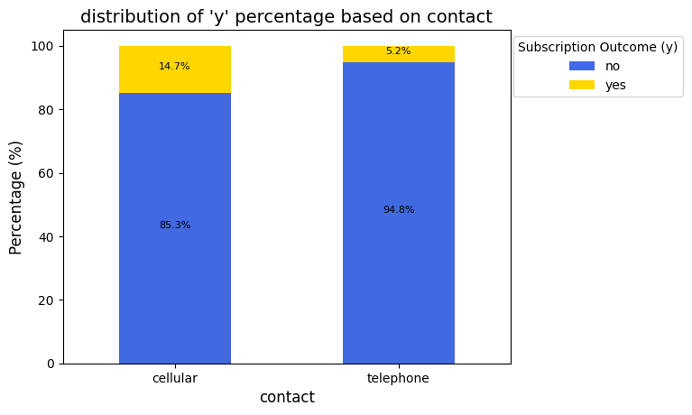

```python
# Plot the count and the percentage distribution of 'y' for each 'contact' category
plot_y_distribution_categorical(df_EDA, 'contact')
```

**Observation(s):**

A significant difference in subscription outcome (y = yes) for contact communication type when using cellular (14.7 %) and telephone (5.2%).

**Note(s) for Model Training:**

Contact communication type seem to have high influence on the likelihood of subscription. To be used for model training.

### Distribution of 'y' Based on Last Contact Month of Year

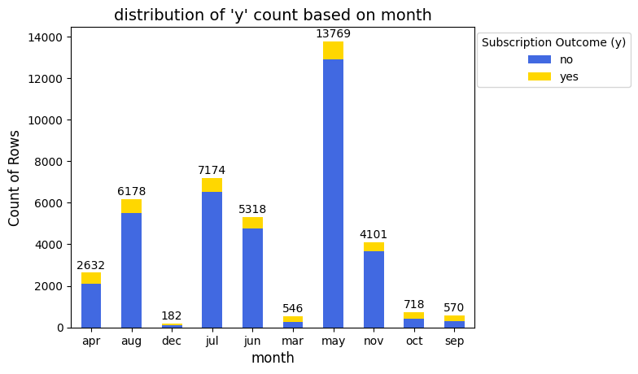

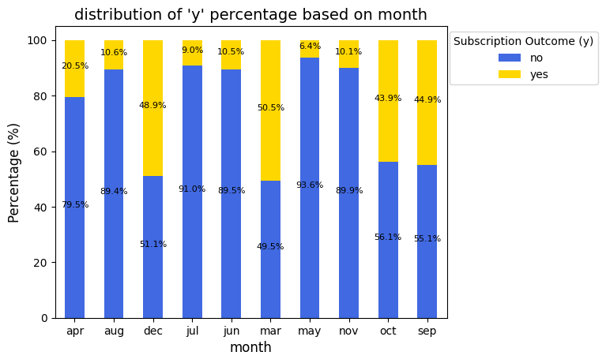

```python
# Plot the count and the percentage distribution of 'y' for each 'month' category
plot_y_distribution_categorical(df_EDA, 'month')
```

**Observation(s):**

Across the last contact month of year, the subscription outcome (y = yes) ranges from 6.4% to 50.5%. Based on current records, Mar, Oct, Sep and Dec have very high percentage of subscription outcome (y = yes) approxiamtely more than 43%. However, all four have relatively smaller number of records compared to the rest of the months. There could be a chance that the high percentage of subscription outcome (y = yes) may be influenced by low frequency of calls within a month rather than the month itself.

**Note(s) for Model Training:**

It is uncertain whether the month or the frequency of call has influence on the likelihood of subscription. Potentially could be excluded for model training after examing the feature importance.

### Distribution of 'y' Based on Last Contact Day of the Week

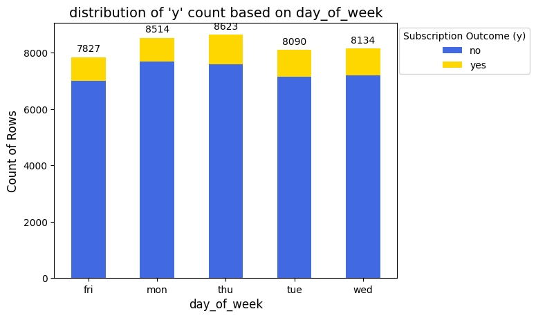

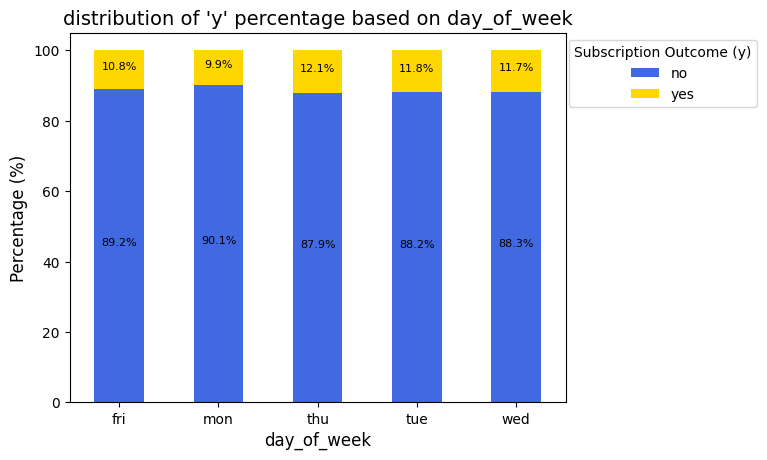

```python
# Plot the count and the percentage distribution of 'y' for each 'day_of_week' category
plot_y_distribution_categorical(df_EDA, 'day_of_week')
```

**Observation(s):**

Across the last contact day of the week, the subscription outcome (y = yes) ranges from 9.9% to 12.1%. Last contact day of the week seems to have no significant difference on the subscription outcome (y = yes).

**Note(s) for Model Training:**

Last contact day of the week seems to have little influence on the likelihood of subscription. Potentially could be excluded for model training after examing the feature importance.

### Distibution of 'y' Based on Outcome of the Previous Marketing Campaign

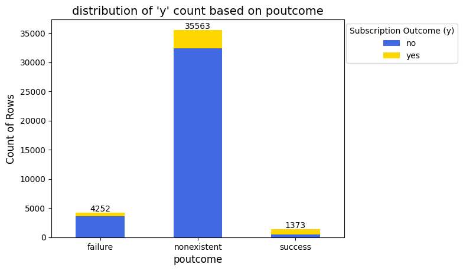

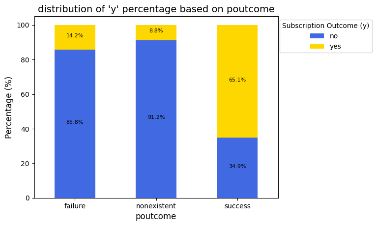

```python
# Plot the count and the percentage distribution of 'y' for each 'poutcome' category
plot_y_distribution_categorical(df_EDA, 'poutcome')
```

**Observation(s):**

Across the outcome of the previous marketing campaign, the subscription outcome (y = yes) ranges from 8.8% to 65.1%.

**Note(s) for Model Training:**

The outcome of the previous marketing campaign seem to have high influence on the likelihood of subscription. To be used for model training.

### Correlation Matrix

```python
# Make 'y' binary
df_EDA['y'] = df_EDA['y'].replace({'no': 0, 'yes': 1})
```

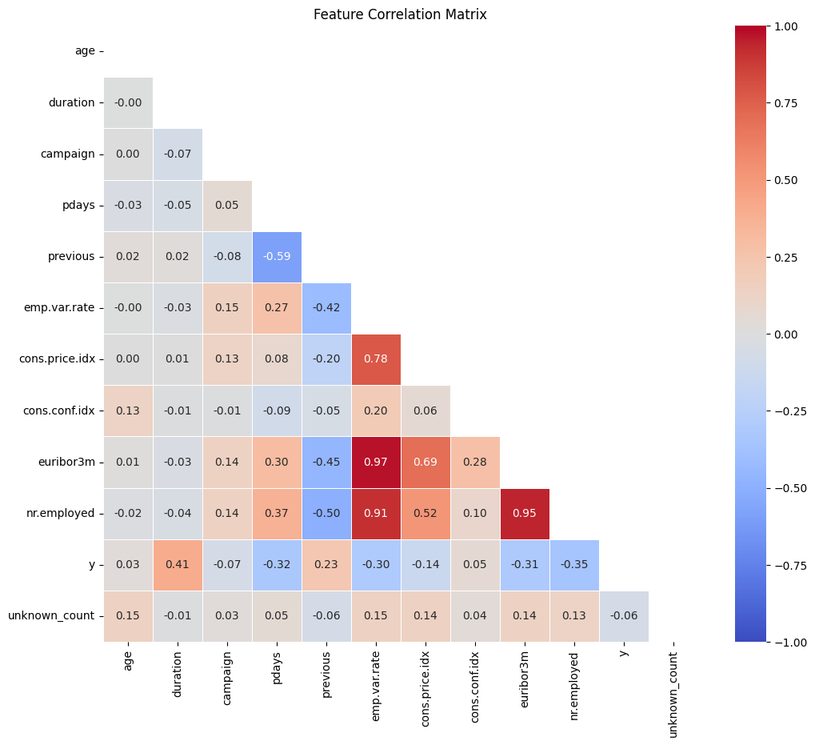

```python
# Compute the correlation matrix (only numeric columns)
corr_matrix = df_EDA.select_dtypes(include=['float64', 'int64']).corr()

mask = np.zeros_like(corr_matrix)
mask[np.triu_indices_from(mask)] = True

# Plot the heatmap
plt.figure(figsize=(12, 10))
sns.heatmap(data=corr_matrix, vmin=-1, vmax=1, mask=mask, annot=True, fmt='.2f', cmap='coolwarm', linewidths=0.5)
plt.title('Feature Correlation Matrix')
plt.show()
```

**Observation(s):**

euribor3m and emp.var.rate has high correlation with other features.

**Note(s) for Model Training:**

For logistic regression, these 2 features will be dropped to reduce issue of multicollinearity.

### Boxplot and Distribution Plot

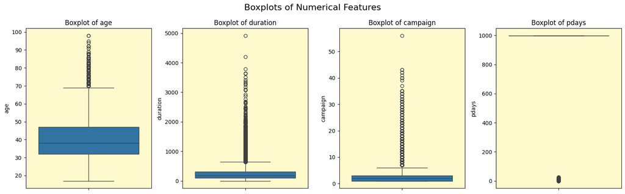

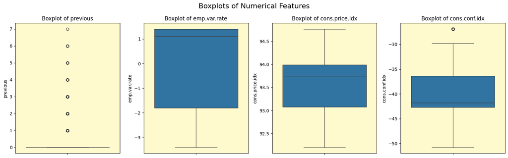

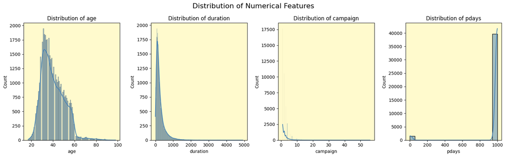

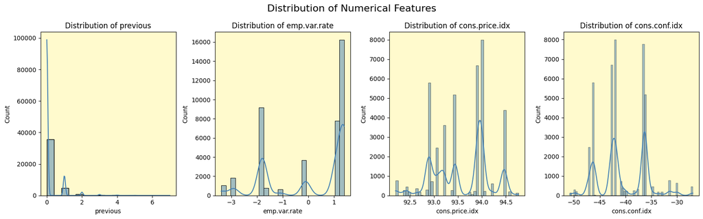

```python
# Define numerical features for boxplots and distributions
features = df.select_dtypes(include=['int64', 'float64']).columns.tolist()

# Boxplots
for i in range(2):
    fig, axes = plt.subplots(ncols=4, figsize=(16, 5))
    fig.suptitle("Boxplots of Numerical Features", fontsize=16)

    for j in range(4):
        if i * 4 + j < len(features):
            sns.boxplot(y=df_EDA[features[i * 4 + j]], ax=axes[j])
            axes[j].set_title(f'Boxplot of {features[i * 4 + j]}', fontsize=12)
            axes[j].set_facecolor('lemonchiffon')

    plt.tight_layout()
    plt.show()

# Distribution Plots
for i in range(2):
    fig, axes = plt.subplots(ncols=4, figsize=(16, 5))
    fig.suptitle("Distribution of Numerical Features", fontsize=16)

    for j in range(4):
        if i * 4 + j < len(features):
            sns.histplot(df_EDA[features[i * 4 + j]], ax=axes[j], kde=True, color='steelblue')
            axes[j].set_title(f'Distribution of {features[i * 4 + j]}', fontsize=12)
            axes[j].set_facecolor('lemonchiffon')

    plt.tight_layout()
    plt.show()
```

# Feature Engineering

## Identify Categorical and Numerical Features

#### Removal of input features

```python
# 1. Drop 'duration' column
# Notes from bank-additional-names.txt:
### This attribute highly affects the output target (e.g., if duration=0 then y="no").
### Yet, the duration is not known before a call is performed. Also, after the end of the call y is obviously known.
### Thus, this input should only be included for benchmark purposes and should be discarded if the intention is to have a realistic predictive model.
df.drop(['duration'], axis=1, inplace=True)

# For Logistic Regression only
# 2. Drop euribor3m and emp.var.rate to reduce multicollienarity
df_logreg = df.copy()
df_logreg.drop(['euribor3m', 'emp.var.rate'], axis=1, inplace=True)
```

```python
# List categorical features and numerical features in df
df_logreg_categorical_features = df_logreg.select_dtypes(include=['object', 'category']).columns.tolist()
df_logreg_numerical_features = df_logreg.select_dtypes(include=['int64', 'float64']).columns.tolist()

print("In df_logreg, Categorical and Numerical Features after binning:")
print("In df_logreg, Categorical Features:", df_logreg_categorical_features)
print("In df_logreg, Numerical Features:", df_logreg_numerical_features)
```

```
In df_logreg, Categorical and Numerical Features after binning:
In df_logreg, Categorical Features: ['job', 'marital', 'education', 'default', 'housing', 'loan', 'contact', 'month', 'day_of_week', 'poutcome', 'y']
In df_logreg, Numerical Features: ['age', 'campaign', 'pdays', 'previous', 'cons.price.idx', 'cons.conf.idx', 'nr.employed']
```

```python
# List categorical features and numerical features in df
df_categorical_features = df.select_dtypes(include=['object', 'category']).columns.tolist()
df_numerical_features = df.select_dtypes(include=['int64', 'float64']).columns.tolist()

print("In df, Categorical and Numerical Features after binning:")
print("In df, Categorical Features:", df_categorical_features)
print("In df, Numerical Features:", df_numerical_features)
```

```
In df, Categorical and Numerical Features after binning:
In df, Categorical Features: ['job', 'marital', 'education', 'default', 'housing', 'loan', 'contact', 'month', 'day_of_week', 'poutcome', 'y']
In df, Numerical Features: ['age', 'campaign', 'pdays', 'previous', 'emp.var.rate', 'cons.price.idx', 'cons.conf.idx', 'euribor3m', 'nr.employed']
```

#### Encode Categorical Variables (One-Hot Encoding)

```python
print("Categorical variables before encoding:")
for col in df_categorical_features:
    print(f"{col}: {df[col].unique()}")
```

```
Categorical variables before encoding:
job: ['housemaid' 'services' 'admin.' 'blue-collar' 'technician' 'retired'
 'management' 'unemployed' 'self-employed' 'unknown' 'entrepreneur'
 'student']
marital: ['married' 'single' 'divorced' 'unknown']
education: ['basic.4y' 'high.school' 'basic.6y' 'basic.9y' 'professional.course'
 'unknown' 'university.degree' 'illiterate']
default: ['no' 'unknown' 'yes']
housing: ['no' 'yes' 'unknown']
loan: ['no' 'yes' 'unknown']
contact: ['telephone' 'cellular']
month: ['may' 'jun' 'jul' 'aug' 'oct' 'nov' 'dec' 'mar' 'apr' 'sep']
day_of_week: ['mon' 'tue' 'wed' 'thu' 'fri']
poutcome: ['nonexistent' 'failure' 'success']
y: ['no' 'yes']
```

> Jo: Amended drop_first from False to True, this will reduce 1 column per categorical_feature and multicollinearity

```python
# For Logistic Regression, drop_first = True, as the model is sensitive to multicollinearity
df_logreg = pd.get_dummies(df_logreg, columns=df_logreg_categorical_features, drop_first=True)

# Print columns after encoding
print("Columns in df_logreg after encoding:")
print(df_logreg.columns)
```

```
Columns in df_logreg after encoding:
Index(['age', 'campaign', 'pdays', 'previous', 'cons.price.idx',
       'cons.conf.idx', 'nr.employed', 'job_blue-collar', 'job_entrepreneur',
       'job_housemaid', 'job_management', 'job_retired', 'job_self-employed',
       'job_services', 'job_student', 'job_technician', 'job_unemployed',
       'job_unknown', 'marital_married', 'marital_single', 'marital_unknown',
       'education_basic.6y', 'education_basic.9y', 'education_high.school',
       'education_illiterate', 'education_professional.course',
       'education_university.degree', 'education_unknown', 'default_unknown',
       'default_yes', 'housing_unknown', 'housing_yes', 'loan_unknown',
       'loan_yes', 'contact_telephone', 'month_aug', 'month_dec', 'month_jul',
       'month_jun', 'month_mar', 'month_may', 'month_nov', 'month_oct',
       'month_sep', 'day_of_week_mon', 'day_of_week_thu', 'day_of_week_tue',
       'day_of_week_wed', 'poutcome_nonexistent', 'poutcome_success', 'y_yes'],
      dtype='object')
```

```python
# For RandomForest and XGBoost, drop_first = False, as the models are not sensitive to multicollinearity and the first feature value may help model with decision splits
df = pd.get_dummies(df, columns=df_categorical_features, drop_first=False)

# Print columns after encoding
print("Columns in df after encoding:")
print(df.columns)
```

```
Columns in df after encoding:
Index(['age', 'campaign', 'pdays', 'previous', 'emp.var.rate',
       'cons.price.idx', 'cons.conf.idx', 'euribor3m', 'nr.employed',
       'job_admin.', 'job_blue-collar', 'job_entrepreneur', 'job_housemaid',
       'job_management', 'job_retired', 'job_self-employed', 'job_services',
       'job_student', 'job_technician', 'job_unemployed', 'job_unknown',
       'marital_divorced', 'marital_married', 'marital_single',
       'marital_unknown', 'education_basic.4y', 'education_basic.6y',
       'education_basic.9y', 'education_high.school', 'education_illiterate',
       'education_professional.course', 'education_university.degree',
       'education_unknown', 'default_no', 'default_unknown', 'default_yes',
       'housing_no', 'housing_unknown', 'housing_yes', 'loan_no',
       'loan_unknown', 'loan_yes', 'contact_cellular', 'contact_telephone',
       'month_apr', 'month_aug', 'month_dec', 'month_jul', 'month_jun',
       'month_mar', 'month_may', 'month_nov', 'month_oct', 'month_sep',
       'day_of_week_fri', 'day_of_week_mon', 'day_of_week_thu',
       'day_of_week_tue', 'day_of_week_wed', 'poutcome_failure',
       'poutcome_nonexistent', 'poutcome_success', 'y_no', 'y_yes'],
      dtype='object')
```